# K Nearest Neighbours Using NBA Player Data

Nicholas Burke

05 December 2019

## Introduction

This project with the use the computer program R will use the K-Nearest-Neighbours algorithm to predict the position of NBA players based on their regular season statistics.

The k-nearest neighbours algorithm predicts unknown values by matching them alongside very or “most” similar known values. Since the KKN model is a straight forward approach based on memory it cannot be summarized in closed-form fashion. Meaning the training samples are required at run-time and predictions are made upon relationship among samples. The value of k in this algorithm can be any value less than the number of rows in the data frame. The aim is to examine a small number of neighbours for better algorithm performance, due to the fact that the less similar the neighbours are to in the data, the worse the prediction will be.

In order to find the most similar NBA players we will use the principle of Euclidean distance, simply measuring the straight-line distance between two players.

First import data from the website basketballreference.com

## NBA Statistics in R

```r
library(ballr)
library (magrittr)
```

```r
library (ggplot2)
library (janitor)
library (scales)
library(dplyr)
library(ggplot2)
library(rsample)
library(recipes)
```

We call the per game statistics from the 2018-2019 NBA regular season. Based on their respective statistics that have been tracked and documented throughout the season.

The statistics include:

• Games

• Games started

• Minutes played

• 2pt & 3pt field goals/attempts

• Free throws/attempts

• Assists, turnovers

• Offensive/ Defensive and Total Rebounds

• Fouls

• Blocks

• Steals

• Total points

In order to view the per game statistics of each player in the NBA for 2019 regular season we must call the function

```r
players <- NBAPerGameStatistics(season = 2019)
head(players)
```

```
## # A tibble: 6 x 31
##      rk player pos     age tm        g    gs    mp    fg   fga fgpercent
##   <dbl> <chr>  <chr> <dbl> <chr> <dbl> <dbl> <dbl> <dbl> <dbl>     <dbl>
## 1     1 Álex ~ SG       25 OKC      31     2  19     1.8   5.1     0.357
## 2     2 Quinc~ PF       28 PHO      10     0  12.3   0.4   1.8     0.222
## 3     3 Jayle~ PG       22 ATL      34     1  12.6   1.1   3.2     0.345
## 4     4 Steve~ C        25 OKC      80    80  33.4   6    10.1     0.595
## 5     5 Bam A~ C        21 MIA      82    28  23.3   3.4   5.9     0.576
## 6     6 Deng ~ SF       21 CLE      19     3  10.2   0.6   1.9     0.306
## # ... with 20 more variables: x3p <dbl>, x3pa <dbl>, x3ppercent <dbl>,
## #   x2p <dbl>, x2pa <dbl>, x2ppercent <dbl>, efgpercent <dbl>, ft <dbl>,
## #   fta <dbl>, ftpercent <dbl>, orb <dbl>, drb <dbl>, trb <dbl>,
## #   ast <dbl>, stl <dbl>, blk <dbl>, tov <dbl>, pf <dbl>, pts <dbl>,
## #   link <chr>
```

Now we will create a data frame with only numeric values and the player’s name and position. Using the following columns

• “pos”,

• “g”

• “gs”

• “player”

• “pos”

• “age”

• “mp”

• “fg”

• “fga”

• “fgpercent”

• “x3p”

• “x3pa”

• “x3ppercent”

• “x2p”

• “x2pa”

• “x2ppercent”

• “efgpercent”

• “ft”

• “fta”

• “ftpercent”

• “orb”

• “drb”

• “trb”

• “ast”

• “stl”

• “blk”

• “tov”

• “pf”

• “pts”

```r
colnames(players)
```

```
##  [1] "rk"         "player"     "pos"        "age"        "tm"
##  [6] "g"          "gs"         "mp"         "fg"         "fga"
## [11] "fgpercent"  "x3p"        "x3pa"       "x3ppercent" "x2p"
## [16] "x2pa"       "x2ppercent" "efgpercent" "ft"         "fta"
## [21] "ftpercent"  "orb"        "drb"        "trb"        "ast"
## [26] "stl"        "blk"        "tov"        "pf"         "pts"
## [31] "link"
```

```r
PerGame<- players %>% select(player, pos, g , gs, age, mp, fg, fga,fgpercent,x3p, x3pa, x3ppercent, x2p,x2pa, x2ppercent, efgpercent,ft,fta,ftpercent,orb,drb,trb,ast,stl,blk,tov,pf,pts)
head(PerGame)
```

```
## # A tibble: 6 x 28
##   player pos       g    gs   age    mp    fg   fga fgpercent   x3p  x3pa
##   <chr>  <chr> <dbl> <dbl> <dbl> <dbl> <dbl> <dbl>     <dbl> <dbl> <dbl>
## 1 Álex ~ SG       31     2    25  19     1.8   5.1     0.357   1.3   4.1
## 2 Quinc~ PF       10     0    28  12.3   0.4   1.8     0.222   0.2   1.5
## 3 Jayle~ PG       34     1    22  12.6   1.1   3.2     0.345   0.7   2.2
## 4 Steve~ C        80    80    25  33.4   6    10.1     0.595   0     0
## 5 Bam A~ C        82    28    21  23.3   3.4   5.9     0.576   0     0.2
## 6 Deng ~ SF       19     3    21  10.2   0.6   1.9     0.306   0.3   1.2
## # ... with 17 more variables: x3ppercent <dbl>, x2p <dbl>, x2pa <dbl>,
## #   x2ppercent <dbl>, efgpercent <dbl>, ft <dbl>, fta <dbl>,
## #   ftpercent <dbl>, orb <dbl>, drb <dbl>, trb <dbl>, ast <dbl>,
## #   stl <dbl>, blk <dbl>, tov <dbl>, pf <dbl>, pts <dbl>
```

Here is the row for the 2019 NBA MVP Giannis Antetokounmpo statistics for the regular season.

```r
Giannis <- filter(PerGame,player == 'Giannis Antetokounmpo')
Giannis
```

```
## # A tibble: 1 x 28
##   player pos       g    gs   age    mp    fg   fga fgpercent   x3p  x3pa
##   <chr>  <chr> <dbl> <dbl> <dbl> <dbl> <dbl> <dbl>     <dbl> <dbl> <dbl>
## 1 Giann~ PF       72    72    24  32.8    10  17.3     0.578   0.7   2.8
## # ... with 17 more variables: x3ppercent <dbl>, x2p <dbl>, x2pa <dbl>,
## #   x2ppercent <dbl>, efgpercent <dbl>, ft <dbl>, fta <dbl>,
## #   ftpercent <dbl>, orb <dbl>, drb <dbl>, trb <dbl>, ast <dbl>,
## #   stl <dbl>, blk <dbl>, tov <dbl>, pf <dbl>, pts <dbl>
```

Now we must normalize and standardize each column because larger variables have a greater effect on the distance between the observations, and hence on the overall KNN classifier, than smaller variables. Thus each variable will have a mean of 0 and a standard deviation of 1.

## Standardizing Data

Now using the scale function in R will now standardize the rest of the PerGame dataset

```r
Standardized.PerGame <- PerGame %>% mutate_at(c( 'g' , 'gs', 'age', 'mp', 'fg', 'fga','fgpercent','x3p', 'x3pa', 'x3ppercent', 'x2p','x2pa', 'x2ppercent', 'efgpercent','ft','fta','ftpercent','orb','drb','trb','ast','stl','blk','tov','pf','pts' ), funs(c(scale(.))))
head(Standardized.PerGame)
```

```
## # A tibble: 6 x 28
##   player pos        g     gs    age      mp     fg    fga fgpercent    x3p
##   <chr>  <chr>  <dbl>  <dbl>  <dbl>   <dbl>  <dbl>  <dbl>     <dbl>  <dbl>
## 1 Álex ~ SG    -0.452 -0.690 -0.276 -0.0294 -0.610 -0.406    -0.730  0.527
## 2 Quinc~ PF    -1.25  -0.768  0.449 -0.772  -1.27  -1.16     -1.96  -0.867
## 3 Jayle~ PG    -0.338 -0.729 -1.00  -0.739  -0.941 -0.838    -0.839 -0.233
## 4 Steve~ C      1.41   2.33  -0.276  1.57    1.37   0.731     1.43  -1.12
## 5 Bam A~ C      1.49   0.315 -1.24   0.447   0.146 -0.224     1.26  -1.12
## 6 Deng ~ SF    -0.909 -0.652 -1.24  -1.00   -1.18  -1.13     -1.19  -0.741
## # ... with 18 more variables: x3pa <dbl>, x3ppercent <dbl>, x2p <dbl>,
## #   x2pa <dbl>, x2ppercent <dbl>, efgpercent <dbl>, ft <dbl>, fta <dbl>,
## #   ftpercent <dbl>, orb <dbl>, drb <dbl>, trb <dbl>, ast <dbl>,
## #   stl <dbl>, blk <dbl>, tov <dbl>, pf <dbl>, pts <dbl>
```

Lets do a quick check on variance of the ‘fg’ column to verify that the scaling worked.

```r
var(Standardized.PerGame[,'fg'])
```

```
##    fg
## fg  1
```

Now will we created train and test split set to run the KNN algorithm. Using random sampling, from the standardized.PerGame data frame, and then pick rows using the randomly shuffled values.

First will we remove all the rows that have a NA value for the KNN function will not work.

```r
Standardized.PerGame1 <- na.omit(Standardized.PerGame)
```

## Training and Test Set

We will create training (70%) set and 30% test set now.

```r
library(caTools)
set.seed(123)
split = sample.split(Standardized.PerGame1$pos, SplitRatio = 0.7)
train = subset(Standardized.PerGame1, split == TRUE)
test = subset(Standardized.PerGame1, split == FALSE)
```

## KNN model

```r
library(class)
predicted.pos <- knn(train[,c( 'g' , 'gs', 'age', 'mp', 'fg', 'fga','fgpercent','x3p', 'x3pa', 'x3ppercent', 'x2p','x2pa', 'x2ppercent', 'efgpercent','ft','fta','ftpercent','orb','drb','trb','ast','stl','blk','tov','pf','pts' )],test[,c( 'g' , 'gs', 'age', 'mp', 'fg', 'fga','fgpercent','x3p', 'x3pa', 'x3ppercent', 'x2p','x2pa', 'x2ppercent', 'efgpercent','ft','fta','ftpercent','orb','drb','trb','ast','stl','blk','tov','pf','pts' )],train$pos,k=5)
predicted.pos
```

```
##   [1] C  SG PG PG PF PF PG C  PG SG PG SF SG SF PG PF PG SG C  PG PF SF SG
##  [24] SF SG SG SF SF PG SG SG PF SG SF SG PG SG PF C  PF PG SF PF SG C  PG
##  [47] SF PF SF PF SF PG SF C  PG SG C  SG C  SF PG C  SG SG SF SG PG SF SG
##  [70] C  C  PF SF SG SF SG SG PF SG SG PG SF SF SF SF SG SG SF SG SF SG SG
##  [93] SG SG PG SG PG SF PF PF SG SG C  PG C  SF SF PG PF C  SF SG PF SF PG
## [116] SG C  PF SG SG SG C  SG SF PG SG SF PF PG PF C  SG SG PF SG PG SG PG
## [139] PG SF SF SF PF C  SF PF PF PF PG SG PG C  SF PF SG SF PF PG C  SF PF
## [162] PG PF PF SF PG PG SG SG SG PF PG SF PF SG SG C  PG SG SG SG PF PF PF
## [185] PG SG C  PF PF
## Levels: C C-PF PF PF-C PF-SF PG SF SF-SG SG SG-PF SG-SF
```

### Misclassification Rate

Now we can calculate the misclassification rate of our model

```r
mean(test$pos != predicted.pos)
```

```
## [1] 0.4497354
```

```r
predicted.pos <- NULL
error.rate <- NULL

for(i in 1:10){
  set.seed(123)
  predicted.pos <- knn(train[,c( 'g' , 'gs', 'age', 'mp', 'fg', 'fga','fgpercent','x3p', 'x3pa', 'x3ppercent', 'x2p','x2pa', 'x2ppercent', 'efgpercent','ft','fta','ftpercent','orb','drb','trb','ast','stl','blk','tov','pf','pts' )],test[,c( 'g' , 'gs', 'age', 'mp', 'fg', 'fga','fgpercent','x3p', 'x3pa', 'x3ppercent', 'x2p','x2pa', 'x2ppercent', 'efgpercent','ft','fta','ftpercent','orb','drb','trb','ast','stl','blk','tov','pf','pts' )],train$pos,k=i)
    error.rate[i] <- mean(test$pos != predicted.pos)
}


print(error.rate)
```

```
##  [1] 0.3862434 0.4497354 0.4285714 0.4126984 0.4603175 0.4391534 0.4391534
##  [8] 0.4232804 0.4656085 0.4285714
```

```r
k.values <- 1:20

  error.df <- data.frame(error.rate,k.values)

  error.df
```

```
##    error.rate k.values
## 1   0.3862434        1
## 2   0.4497354        2
## 3   0.4285714        3
## 4   0.4126984        4
## 5   0.4603175        5
## 6   0.4391534        6
## 7   0.4391534        7
## 8   0.4232804        8
## 9   0.4656085        9
## 10  0.4285714       10
## 11  0.3862434       11
## 12  0.4497354       12
## 13  0.4285714       13
## 14  0.4126984       14
## 15  0.4603175       15
## 16  0.4391534       16
## 17  0.4391534       17
## 18  0.4232804       18
## 19  0.4656085       19
## 20  0.4285714       20
```

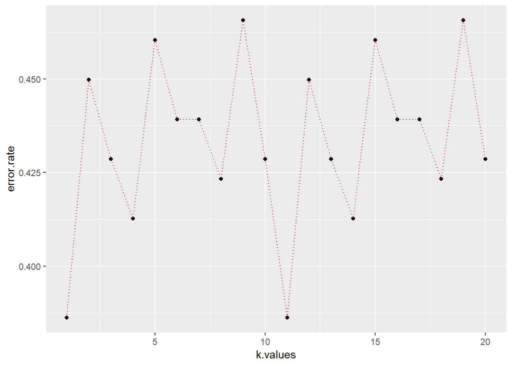

```r
 ggplot(error.df,aes(x=k.values,y=error.rate)) + geom_point()+ geom_line(lty="dotted",color='red')
```